# RMET Analysis

Ellen Herschel, Colin McDaniel, Sherry Zhang

11/29/2021

# Read in Data

```r
# Import R data
alldata <- read.csv("~/Desktop/Coursework/Fall 2021/Multilevel Modeling/psyc575/Music_Sports_Empathy/Music_Sports_Empathy/Full Data Sets/sport_music_dat_mlm_long2.csv")

#alldata <- read.csv("sport_music_dat_mlm_long2.csv")

widedata<- read.csv("~/Desktop/Coursework/Fall 2021/Multilevel Modeling/psyc575/Music_Sports_Empathy/Music_Sports_Empathy/Full Data Sets/sport_music_dat_mlm_wide.csv")

#widedata<- read.csv("sport_music_dat_mlm_wide.csv")
```

#Factor, Get rid of NAs

```r
# Code Year and Group as factors
alldata$year <- factor(alldata$year)
alldata$group <- factor(alldata$group)

alldata$time<-as.integer(alldata$year)

# Remove NAs from data
alldata1<- drop_na(alldata, wasi_vci, group, rmet_percent_correct, wasi_age)
```

# Mean-center variables

```r
# Mean-center Age
alldata1 <- alldata1 %>%
  group_by(id) %>%   # operate within individual
  mutate(age_pm = mean(wasi_age),   # create individual means (the same as `meanses`)
         age_pmc = wasi_age - age_pm) %>%   # cluster-mean centered
  ungroup()  # exit the "editing within groups" mode

alldata1 %>%
  select(id, wasi_age, age_pm, age_pmc)
```

| id | wasi_age | age_pm | age_pmc |
| --- | --- | --- | --- |
| M102 | 6.441096 | 9.165753 | -2.724657535 |
| M106 | 7.213699 | 8.690411 | -1.476712328 |
| M107 | 7.334247 | 9.258630 | -1.924383561 |
| M108 | 6.339726 | 8.992694 | -2.652968037 |
| M109 | 6.189041 | 8.153425 | -1.964383562 |
| M112 | 6.717808 | 8.091781 | -1.373972603 |
| M113 | 7.002740 | 8.903014 | -1.900273972 |
| S101 | 7.624658 | 9.191781 | -1.567123287 |
| S103 | 6.301370 | 9.006393 | -2.705022831 |
| S104 | 6.843836 | 8.927671 | -2.083835617 |

[output cut: 367 more lines]

```r
# Mean-center verbal ability
alldata1 <- alldata1 %>%
  group_by(id) %>%   # operate within individual
  mutate(verbal_pm = mean(wasi_vci),   # create individual means (the same as `meanses`)
         verbal_pmc = wasi_vci - verbal_pm) %>%   # cluster-mean centered
  ungroup()  # exit the "editing within groups" mode

alldata1 %>%
  select(id, wasi_vci, verbal_pm, verbal_pmc)
```

| id | wasi_vci | verbal_pm | verbal_pmc |
| --- | --- | --- | --- |
| M102 | 99 | 104.00000 | -5.0000000 |
| M106 | 98 | 96.00000 | 2.0000000 |
| M107 | 86 | 76.60000 | 9.4000000 |
| M108 | 102 | 110.33333 | -8.3333333 |
| M109 | 98 | 105.20000 | -7.2000000 |
| M112 | 105 | 105.50000 | -0.5000000 |
| M113 | 85 | 89.20000 | -4.2000000 |
| S101 | 77 | 81.25000 | -4.2500000 |
| S103 | 105 | 101.16667 | 3.8333333 |
| S104 | 102 | 97.20000 | 4.8000000 |

[output cut: 367 more lines]

```r
datasummary_skim(alldata1 %>%
                   select(rmet_percent_correct, time, wasi_age, group, wasi_vci ))
```

|  | Unique (#) | Missing (%) | Mean | SD | Min | Median | Max |  |
| --- | --- | --- | --- | --- | --- | --- | --- | --- |
| rmet_percent_correct | 25 | 0 | 0.6 | 0.1 | 0.2 | 0.6 | 0.9 |  |
| time | 6 | 0 | 3.1 | 1.6 | 1.0 | 3.0 | 6.0 |  |
| wasi_age | 350 | 0 | 9.1 | 2.0 | 5.7 | 9.0 | 14.1 |  |
| wasi_vci | 62 | 0 | 98.1 | 11.9 | 68.0 | 98.0 | 142.0 |  |

# Check for differences in baseline Age

```r
widedata$group <- factor(widedata$group)

agebase<-aov(wasi_age_Y1~group, widedata)
summary(agebase)
```

```
##             Df Sum Sq Mean Sq F value  Pr(>F)
## group        2  2.757  1.3786    5.11 0.00815 **
## Residuals   80 21.582  0.2698
## ---
## Signif. codes:  0 '***' 0.001 '**' 0.01 '*' 0.05 '.' 0.1 ' ' 1
```

# Attrition Analysis

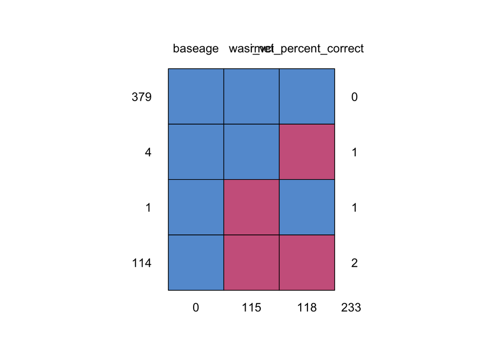

```
##     baseage wasi_vci rmet_percent_correct
## 379       1        1                    1   0
## 4         1        1                    0   1
## 1         1        0                    1   1
## 114       1        0                    0   2
##           0      115                  118 233
```

```r
# Replace incorrectly placed 0s with NA
alldata$rmet_percent_correct[alldata$rmet_percent_correct == 0] <- NA

# Examine missing data patterns
md.pattern(alldata[,c("rmet_percent_correct", "baseage", "wasi_vci")])
```

```r
# Attrition analysis setup
alldata$miss_rmet_percent_correct <- ifelse(is.na(alldata$rmet_percent_correct), 1, 0)
alldata$miss_baseage <- ifelse(is.na(alldata$baseage), 1, 0)
alldata$miss_wasi_vci <- ifelse(is.na(alldata$wasi_vci), 1, 0)

# Test whether RMET is missing completely at random
t.test(alldata$baseage[alldata$miss_rmet_percent_correct==0], alldata$baseage[alldata$miss_rmet_percent_correct==1], alternative = "two.sided", conf.level = .95, var.equal = TRUE)
```

```
##
##  Two Sample t-test
##
## data:  alldata$baseage[alldata$miss_rmet_percent_correct == 0] and alldata$baseage[alldata$miss_rmet_percent_correct == 1]
## t = 0.59985, df = 496, p-value = 0.5489
## alternative hypothesis: true difference in means is not equal to 0
## 95 percent confidence interval:
##  -0.07802237  0.14660155
## sample estimates:
## mean of x mean of y
##  6.817433  6.783144
```

```r
t.test(alldata$wasi_vci[alldata$miss_rmet_percent_correct==0], alldata$wasi_vci[alldata$miss_rmet_percent_correct==1], alternative = "two.sided", conf.level = .95, var.equal = TRUE)
```

```
##
##  Two Sample t-test
##
## data:  alldata$wasi_vci[alldata$miss_rmet_percent_correct == 0] and alldata$wasi_vci[alldata$miss_rmet_percent_correct == 1]
## t = 0.023246, df = 381, p-value = 0.9815
## alternative hypothesis: true difference in means is not equal to 0
## 95 percent confidence interval:
##  -11.68830  11.96798
## sample estimates:
## mean of x mean of y
##  98.13984  98.00000
```

```r
# Test whether wasi_vci is missing completely at random
t.test(alldata$rmet_percent_correct[alldata$miss_wasi_vci==0], alldata$rmet_percent_correct[alldata$miss_wasi_vci==1], alternative = "two.sided", conf.level = .95, var.equal = TRUE)
```

```
##
##  Two Sample t-test
##
## data:  alldata$rmet_percent_correct[alldata$miss_wasi_vci == 0] and alldata$rmet_percent_correct[alldata$miss_wasi_vci == 1]
## t = -1.0105, df = 378, p-value = 0.3129
## alternative hypothesis: true difference in means is not equal to 0
## 95 percent confidence interval:
##  -0.4424539  0.1420532
## sample estimates:
## mean of x mean of y
## 0.6355140 0.7857143
```

```r
t.test(alldata$baseage[alldata$miss_wasi_vci==0], alldata$baseage[alldata$miss_wasi_vci==1], alternative = "two.sided", conf.level = .95, var.equal = TRUE)
```

```
##
##  Two Sample t-test
##
## data:  alldata$baseage[alldata$miss_wasi_vci == 0] and alldata$baseage[alldata$miss_wasi_vci == 1]
## t = 0.80517, df = 496, p-value = 0.4211
## alternative hypothesis: true difference in means is not equal to 0
## 95 percent confidence interval:
##  -0.06686212  0.15971411
## sample estimates:
## mean of x mean of y
##  6.820029  6.773603
```

# Check assumptions

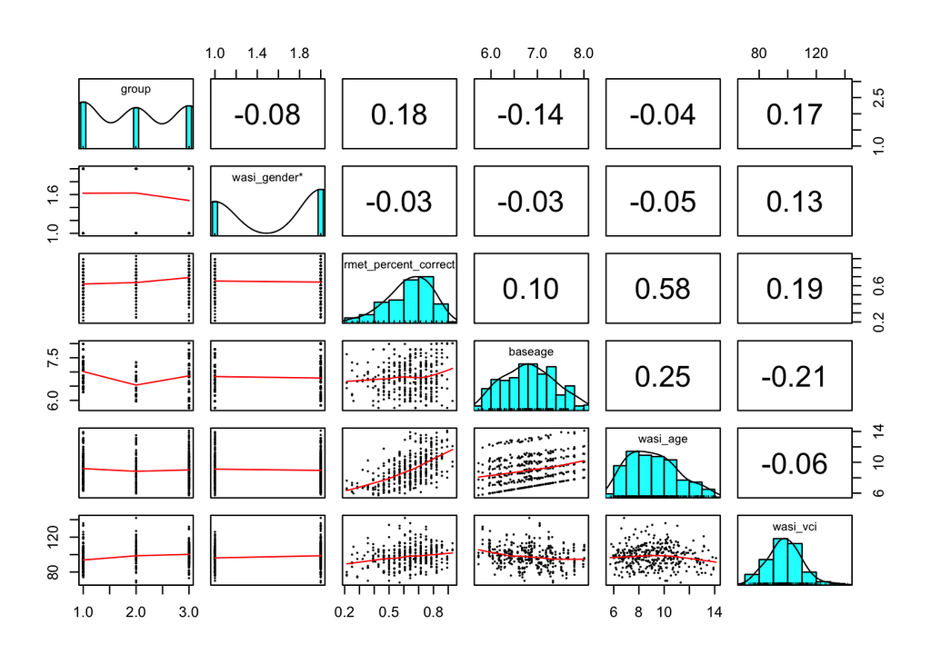

```r
alldata1 %>%
  # Select the variables to be used
  select(group, wasi_gender, rmet_percent_correct, baseage, wasi_age, wasi_vci) %>%
  psych::pairs.panels(ellipses = FALSE, cex = 0.2, cex.cor = 1)
```

The data for rmet_percent_correct, baseage, and wasi_vci (the continuous variables being included in the model) appear relatively normal.

# Write Down Model Equations

Lv-1:
$$\mathrm{empathyRMET}_{ti} = \beta_{0i} + \beta_{1i}\mathrm{time}_{ti} + \beta_{2i}\mathrm{verbalpmc}_{ti} + e_{ti}$$
Lv-2:
$$\beta_{0i} = \gamma_{00} + \gamma_{01}\mathrm{baseage}_i + \gamma_{02}\mathrm{verbalpm_i} + \gamma_{03}\mathrm{group}_i+ u_{0i}$$
$$\beta_{1i} = \gamma_{10} + \gamma_{11}\mathrm{group}_i + u_{1i}$$
$$\beta_{2i} = \gamma_{20} + u_{2i}$$

# Baseline Model

```r
#model with just base interaction of year and group, and no random slopes
m0 <- glmmTMB(rmet_percent_correct ~ time + (1 | id),
    data = alldata1,
)

summary(m0)
```

```
##  Family: gaussian  ( identity )
## Formula:          rmet_percent_correct ~ time + (1 | id)
## Data: alldata1
##
##      AIC      BIC   logLik deviance df.resid
##   -580.4   -564.7    294.2   -588.4      373
##
## Random effects:
##
## Conditional model:
##  Groups   Name        Variance Std.Dev.
##  id       (Intercept) 0.005992 0.07741
##  Residual             0.009209 0.09596
## Number of obs: 377, groups:  id, 83
##
## Dispersion estimate for gaussian family (sigma^2): 0.00921
##
## Conditional model:
##             Estimate Std. Error z value Pr(>|z|)
## (Intercept)  0.47943    0.01368   35.04   <2e-16 ***
## time         0.04782    0.00314   15.23   <2e-16 ***
## ---
## Signif. codes:  0 '***' 0.001 '**' 0.01 '*' 0.05 '.' 0.1 ' ' 1
```

# Add in and test covariates and random slopes

```r
#model

m1 <- glmmTMB(rmet_percent_correct ~ time + group + (1 | id),
    data = alldata1,
)

summary(m1)
```

```
##  Family: gaussian  ( identity )
## Formula:          rmet_percent_correct ~ time + group + (1 | id)
## Data: alldata1
##
##      AIC      BIC   logLik deviance df.resid
##   -584.2   -560.6    298.1   -596.2      371
##
## Random effects:
##
## Conditional model:
##  Groups   Name        Variance Std.Dev.
##  id       (Intercept) 0.005162 0.07185
##  Residual             0.009232 0.09608
## Number of obs: 377, groups:  id, 83
##
## Dispersion estimate for gaussian family (sigma^2): 0.00923
##
## Conditional model:
##             Estimate Std. Error z value Pr(>|z|)
## (Intercept) 0.457435   0.018556  24.651  < 2e-16 ***
## time        0.048029   0.003138  15.305  < 2e-16 ***
## groupMusic  0.005474   0.023484   0.233  0.81569
## groupSport  0.060771   0.023148   2.625  0.00866 **
## ---
## Signif. codes:  0 '***' 0.001 '**' 0.01 '*' 0.05 '.' 0.1 ' ' 1
```

```r
anova(m0, m1)
```

|  | Df | AIC | BIC | logLik | deviance | Chisq | Chi Df | Pr(>Chisq) |
| --- | --- | --- | --- | --- | --- | --- | --- | --- |
| m0 | 4 | -580.4051 | -564.6761 | 294.2025 | -588.4051 | NA | NA | NA |
| m1 | 6 | -584.1777 | -560.5842 | 298.0888 | -596.1777 | 7.772584 | 2 | 0.0205213 |

```r
#m1 sig

#add interaction of year and group
m2 <- glmmTMB(rmet_percent_correct ~ time*group + (1 | id),
    data = alldata1,
)
summary(m2)
```

```
##  Family: gaussian  ( identity )
## Formula:          rmet_percent_correct ~ time * group + (1 | id)
## Data: alldata1
##
##      AIC      BIC   logLik deviance df.resid
##   -580.9   -549.4    298.4   -596.9      369
##
## Random effects:
##
## Conditional model:
##  Groups   Name        Variance Std.Dev.
##  id       (Intercept) 0.005231 0.07233
##  Residual             0.009190 0.09586
## Number of obs: 377, groups:  id, 83
##
## Dispersion estimate for gaussian family (sigma^2): 0.00919
##
## Conditional model:
##                  Estimate Std. Error z value Pr(>|z|)
## (Intercept)      0.449508   0.022333  20.128   <2e-16 ***
## time             0.050684   0.005194   9.759   <2e-16 ***
## groupMusic       0.024444   0.032697   0.748   0.4547
## groupSport       0.066982   0.032154   2.083   0.0372 *
## time:groupMusic -0.006417   0.007659  -0.838   0.4021
## time:groupSport -0.002090   0.007514  -0.278   0.7808
## ---
## Signif. codes:  0 '***' 0.001 '**' 0.01 '*' 0.05 '.' 0.1 ' ' 1
```

```r
anova(m1, m2) #not sig, but this is what we want to test
```

|  | Df | AIC | BIC | logLik | deviance | Chisq | Chi Df | Pr(>Chisq) |
| --- | --- | --- | --- | --- | --- | --- | --- | --- |
| m1 | 6 | -584.1777 | -560.5842 | 298.0888 | -596.1777 | NA | NA | NA |
| m2 | 8 | -580.8954 | -549.4374 | 298.4477 | -596.8954 | 0.7176995 | 2 | 0.6984793 |

```r
#add more covariates
#verbal (person mean-centered)
m3 <- glmmTMB(rmet_percent_correct ~ time*group + verbal_pmc + (1 | id),
    data = alldata1,
)
summary(m3)
```

```
##  Family: gaussian  ( identity )
## Formula:          rmet_percent_correct ~ time * group + verbal_pmc + (1 | id)
## Data: alldata1
##
##      AIC      BIC   logLik deviance df.resid
##   -582.6   -547.2    300.3   -600.6      368
##
## Random effects:
##
## Conditional model:
##  Groups   Name        Variance Std.Dev.
##  id       (Intercept) 0.005267 0.07257
##  Residual             0.009074 0.09526
## Number of obs: 377, groups:  id, 83
##
## Dispersion estimate for gaussian family (sigma^2): 0.00907
##
## Conditional model:
##                   Estimate Std. Error z value Pr(>|z|)
## (Intercept)      0.4484148  0.0222778  20.128   <2e-16 ***
## time             0.0510449  0.0051659   9.881   <2e-16 ***
## groupMusic       0.0275247  0.0326436   0.843   0.3991
## groupSport       0.0657699  0.0320692   2.051   0.0403 *
## verbal_pmc       0.0015570  0.0008083   1.926   0.0541 .
## time:groupMusic -0.0074822  0.0076315  -0.980   0.3269
## time:groupSport -0.0016878  0.0074716  -0.226   0.8213
## ---
## Signif. codes:  0 '***' 0.001 '**' 0.01 '*' 0.05 '.' 0.1 ' ' 1
```

```r
anova(m2, m3)
```

|  | Df | AIC | BIC | logLik | deviance | Chisq | Chi Df | Pr(>Chisq) |
| --- | --- | --- | --- | --- | --- | --- | --- | --- |
| m2 | 8 | -580.8954 | -549.4374 | 298.4477 | -596.8954 | NA | NA | NA |
| m3 | 9 | -582.5815 | -547.1913 | 300.2908 | -600.5815 | 3.686173 | 1 | 0.05486537 |

```r
#is sig .055/2.

#verbal (person mean)
m4 <- glmmTMB(rmet_percent_correct ~ time*group + verbal_pmc+ verbal_pm + (1 | id),
    data = alldata1,
)
summary(m4)
```

```
##  Family: gaussian  ( identity )
## Formula:
## rmet_percent_correct ~ time * group + verbal_pmc + verbal_pm +      (1 | id)
## Data: alldata1
##
##      AIC      BIC   logLik deviance df.resid
##   -586.0   -546.7    303.0   -606.0      367
##
## Random effects:
##
## Conditional model:
##  Groups   Name        Variance Std.Dev.
##  id       (Intercept) 0.004717 0.06868
##  Residual             0.009095 0.09537
## Number of obs: 377, groups:  id, 83
##
## Dispersion estimate for gaussian family (sigma^2): 0.0091
##
## Conditional model:
##                   Estimate Std. Error z value Pr(>|z|)
## (Intercept)      0.2417879  0.0899315   2.689  0.00718 **
## time             0.0512355  0.0051638   9.922  < 2e-16 ***
## groupMusic       0.0222617  0.0321110   0.693  0.48814
## groupSport       0.0600569  0.0315657   1.903  0.05709 .
## verbal_pmc       0.0015520  0.0008093   1.918  0.05516 .
## verbal_pm        0.0021545  0.0009093   2.369  0.01782 *
## time:groupMusic -0.0076815  0.0076256  -1.007  0.31378
## time:groupSport -0.0024215  0.0074722  -0.324  0.74589
## ---
## Signif. codes:  0 '***' 0.001 '**' 0.01 '*' 0.05 '.' 0.1 ' ' 1
```

```r
anova(m3, m4)
```

|  | Df | AIC | BIC | logLik | deviance | Chisq | Chi Df | Pr(>Chisq) |
| --- | --- | --- | --- | --- | --- | --- | --- | --- |
| m3 | 9 | -582.5815 | -547.1913 | 300.2908 | -600.5815 | NA | NA | NA |
| m4 | 10 | -585.9742 | -546.6518 | 302.9871 | -605.9742 | 5.392684 | 1 | 0.02022134 |

```r
#is sig (p val divided by 2)

# age
m5 <- glmmTMB(rmet_percent_correct ~ time*group + verbal_pmc+ verbal_pm + baseage + (1 | id),
    data = alldata1,
)
summary(m5)
```

```
##  Family: gaussian  ( identity )
## Formula:
## rmet_percent_correct ~ time * group + verbal_pmc + verbal_pm +
##     baseage + (1 | id)
## Data: alldata1
##
##      AIC      BIC   logLik deviance df.resid
##   -592.8   -549.5    307.4   -614.8      366
##
## Random effects:
##
## Conditional model:
##  Groups   Name        Variance Std.Dev.
##  id       (Intercept) 0.004117 0.06416
##  Residual             0.009053 0.09515
## Number of obs: 377, groups:  id, 83
##
## Dispersion estimate for gaussian family (sigma^2): 0.00905
##
## Conditional model:
##                   Estimate Std. Error z value Pr(>|z|)
## (Intercept)     -0.1934962  0.1675858  -1.155  0.24825
## time             0.0509990  0.0051416   9.919  < 2e-16 ***
## groupMusic       0.0438757  0.0321857   1.363  0.17282
## groupSport       0.0643809  0.0308639   2.086  0.03698 *
## verbal_pmc       0.0015507  0.0008074   1.921  0.05478 .
## verbal_pm        0.0027918  0.0008928   3.127  0.00177 **
## baseage          0.0534878  0.0177025   3.021  0.00252 **
## time:groupMusic -0.0071294  0.0075964  -0.939  0.34797
## time:groupSport -0.0019294  0.0074428  -0.259  0.79546
## ---
## Signif. codes:  0 '***' 0.001 '**' 0.01 '*' 0.05 '.' 0.1 ' ' 1
```

```r
anova(m4, m5)
```

|  | Df | AIC | BIC | logLik | deviance | Chisq | Chi Df | Pr(>Chisq) |
| --- | --- | --- | --- | --- | --- | --- | --- | --- |
| m4 | 10 | -585.9742 | -546.6518 | 302.9871 | -605.9742 | NA | NA | NA |
| m5 | 11 | -592.8045 | -549.5498 | 307.4022 | -614.8045 | 8.830254 | 1 | 0.002962771 |

```r
# is sig

#gender
m6 <- glmmTMB(rmet_percent_correct ~ time*group + verbal_pmc+ verbal_pm + baseage + wasi_gender + (1 | id),
    data = alldata1,
)
summary(m6)
```

```
##  Family: gaussian  ( identity )
## Formula:
## rmet_percent_correct ~ time * group + verbal_pmc + verbal_pm +
##     baseage + wasi_gender + (1 | id)
## Data: alldata1
##
##      AIC      BIC   logLik deviance df.resid
##   -590.8   -543.6    307.4   -614.8      365
##
## Random effects:
##
## Conditional model:
##  Groups   Name        Variance Std.Dev.
##  id       (Intercept) 0.004111 0.06411
##  Residual             0.009055 0.09516
## Number of obs: 377, groups:  id, 83
##
## Dispersion estimate for gaussian family (sigma^2): 0.00905
##
## Conditional model:
##                   Estimate Std. Error z value Pr(>|z|)
## (Intercept)     -0.1939917  0.1675350  -1.158  0.24690
## time             0.0509997  0.0051419   9.919  < 2e-16 ***
## groupMusic       0.0438432  0.0321804   1.362  0.17307
## groupSport       0.0641975  0.0308781   2.079  0.03761 *
## verbal_pmc       0.0015503  0.0008075   1.920  0.05487 .
## verbal_pm        0.0028137  0.0009021   3.119  0.00181 **
## baseage          0.0535217  0.0176957   3.025  0.00249 **
## wasi_genderm    -0.0030247  0.0181809  -0.166  0.86787
## time:groupMusic -0.0071295  0.0075969  -0.938  0.34800
## time:groupSport -0.0019686  0.0074469  -0.264  0.79151
## ---
## Signif. codes:  0 '***' 0.001 '**' 0.01 '*' 0.05 '.' 0.1 ' ' 1
```

```r
anova(m5, m6)
```

|  | Df | AIC | BIC | logLik | deviance | Chisq | Chi Df | Pr(>Chisq) |
| --- | --- | --- | --- | --- | --- | --- | --- | --- |
| m5 | 11 | -592.8045 | -549.5498 | 307.4022 | -614.8045 | NA | NA | NA |
| m6 | 12 | -590.8321 | -543.6452 | 307.4161 | -614.8321 | 0.02765766 | 1 | 0.8679162 |

```r
#not sig, gender doesnt seem to improve the model


#test for random slopes

#time
m5.1 <- glmmTMB(rmet_percent_correct ~ time*group + verbal_pmc+ verbal_pm + baseage +  (time | id),
    data = alldata1,
)
summary(m5.1)
```

```
##  Family: gaussian  ( identity )
## Formula:
## rmet_percent_correct ~ time * group + verbal_pmc + verbal_pm +
##     baseage + (time | id)
## Data: alldata1
##
##      AIC      BIC   logLik deviance df.resid
##   -612.1   -561.0    319.1   -638.1      364
##
## Random effects:
##
## Conditional model:
##  Groups   Name        Variance  Std.Dev. Corr
##  id       (Intercept) 0.0157821 0.12563
##           time        0.0004854 0.02203  -0.94
##  Residual             0.0075209 0.08672
## Number of obs: 377, groups:  id, 83
##
## Dispersion estimate for gaussian family (sigma^2): 0.00752
##
## Conditional model:
##                   Estimate Std. Error z value Pr(>|z|)
## (Intercept)      0.0406231  0.1631677   0.249   0.8034
## time             0.0511949  0.0062372   8.208 2.25e-16 ***
## groupMusic       0.0246925  0.0421612   0.586   0.5581
## groupSport       0.0569585  0.0408622   1.394   0.1633
## verbal_pmc       0.0015453  0.0007791   1.984   0.0473 *
## verbal_pm        0.0022014  0.0008340   2.640   0.0083 **
## baseage          0.0280537  0.0172045   1.631   0.1030
## time:groupMusic -0.0029302  0.0091956  -0.319   0.7500
## time:groupSport  0.0009544  0.0090237   0.106   0.9158
## ---
## Signif. codes:  0 '***' 0.001 '**' 0.01 '*' 0.05 '.' 0.1 ' ' 1
```

```r
anova(m5, m5.1)
```

|  | Df | AIC | BIC | logLik | deviance | Chisq | Chi Df | Pr(>Chisq) |
| --- | --- | --- | --- | --- | --- | --- | --- | --- |
| m5 | 11 | -592.8045 | -549.5498 | 307.4022 | -614.8045 | NA | NA | NA |
| m5.1 | 13 | -612.1064 | -560.9873 | 319.0532 | -638.1064 | 23.30196 | 2 | 8.710523e-06 |

```r
#this is sig

#verbal
m5.2 <- glmmTMB(rmet_percent_correct ~ time*group + verbal_pmc+ verbal_pm + baseage + (time*verbal_pmc | id),
    data = alldata1,
        # The default optimizer did not converge; try optim
    control = glmmTMBControl(
        optimizer = optim,
        optArgs = list(method = "BFGS")
    )
)
summary(m5.2)
```

```
##  Family: gaussian  ( identity )
## Formula:
## rmet_percent_correct ~ time * group + verbal_pmc + verbal_pm +
##     baseage + (time * verbal_pmc | id)
## Data: alldata1
##
##      AIC      BIC   logLik deviance df.resid
##       NA       NA       NA       NA      357
##
## Random effects:
##
## Conditional model:
##  Groups   Name            Variance  Std.Dev.  Corr
##  id       (Intercept)     1.954e-02 1.398e-01
##           time            1.075e-11 3.279e-06  1.00
##           verbal_pmc      1.134e-12 1.065e-06 -0.98 -0.98
##           time:verbal_pmc 7.262e-89 8.522e-45  0.81  0.82 -0.84
##  Residual                 1.001e-02 1.000e-01
## Number of obs: 377, groups:  id, 83
##
## Dispersion estimate for gaussian family (sigma^2): 0.01
##
## Conditional model:
##                   Estimate Std. Error z value Pr(>|z|)
## (Intercept)     -0.7786335  0.3010266  -2.587  0.00969 **
## time             0.0580326  0.0055562  10.445  < 2e-16 ***
## groupMusic       0.3826454  0.0176095  21.729  < 2e-16 ***
## groupSport       0.0622234  0.0442242   1.407  0.15943
## verbal_pmc       0.0001938  0.0008583   0.226  0.82139
## verbal_pm        0.0035607  0.0016535   2.153  0.03129 *
## baseage          0.1249099  0.0311506   4.010 6.08e-05 ***
## time:groupMusic -0.0263173  0.0082608  -3.186  0.00144 **
## time:groupSport -0.0365411  0.0084986  -4.300 1.71e-05 ***
## ---
## Signif. codes:  0 '***' 0.001 '**' 0.01 '*' 0.05 '.' 0.1 ' ' 1
```

```r
#model convergence problem?

anova(m5.1, m5.2)
```

|  | Df | AIC | BIC | logLik | deviance | Chisq | Chi Df | Pr(>Chisq) |
| --- | --- | --- | --- | --- | --- | --- | --- | --- |
| m5.1 | 13 | -612.1064 | -560.9873 | 319.0532 | -638.1064 | NA | NA | NA |
| m5.2 | 20 | NA | NA | NA | NA | NA | 7 | NA |

```r
#not sig

confint(m5.1, parm = "beta_")
```

```
##                         2.5 %      97.5 %     Estimate
## (Intercept)     -2.791798e-01 0.360425944  0.040623090
## time             3.897020e-02 0.063419689  0.051194943
## groupMusic      -5.794197e-02 0.107326982  0.024692508
## groupSport      -2.312987e-02 0.137046855  0.056958495
## verbal_pmc       1.833934e-05 0.003072183  0.001545261
## verbal_pm        5.668502e-04 0.003836045  0.002201448
## baseage         -5.666508e-03 0.061773897  0.028053695
## time:groupMusic -2.095330e-02 0.015092931 -0.002930186
## time:groupSport -1.673178e-02 0.018640547  0.000954384
```

# Here’s our final model

```r
summary(m5.1)
```

```
##  Family: gaussian  ( identity )
## Formula:
## rmet_percent_correct ~ time * group + verbal_pmc + verbal_pm +
##     baseage + (time | id)
## Data: alldata1
##
##      AIC      BIC   logLik deviance df.resid
##   -612.1   -561.0    319.1   -638.1      364
##
## Random effects:
##
## Conditional model:
##  Groups   Name        Variance  Std.Dev. Corr
##  id       (Intercept) 0.0157821 0.12563
##           time        0.0004854 0.02203  -0.94
##  Residual             0.0075209 0.08672
## Number of obs: 377, groups:  id, 83
##
## Dispersion estimate for gaussian family (sigma^2): 0.00752
##
## Conditional model:
##                   Estimate Std. Error z value Pr(>|z|)
## (Intercept)      0.0406231  0.1631677   0.249   0.8034
## time             0.0511949  0.0062372   8.208 2.25e-16 ***
## groupMusic       0.0246925  0.0421612   0.586   0.5581
## groupSport       0.0569585  0.0408622   1.394   0.1633
## verbal_pmc       0.0015453  0.0007791   1.984   0.0473 *
## verbal_pm        0.0022014  0.0008340   2.640   0.0083 **
## baseage          0.0280537  0.0172045   1.631   0.1030
## time:groupMusic -0.0029302  0.0091956  -0.319   0.7500
## time:groupSport  0.0009544  0.0090237   0.106   0.9158
## ---
## Signif. codes:  0 '***' 0.001 '**' 0.01 '*' 0.05 '.' 0.1 ' ' 1
```

rmet_percent_correct ~ time * group + verbal_pmc + verbal_pm +  
baseage + (time | id)

# Write Down Final Model Equations

Lv-1:
$$\mathrm{empathyRMET}_{ti} = \beta_{0i} + \beta_{1i}\mathrm{time}_{ti} + \beta_{2i}\mathrm{verbalpmc}_{ti} + e_{ti}$$
Lv-2:
$$\beta_{0i} = \gamma_{00} + \gamma_{01}\mathrm{baseage}_i + \gamma_{02}\mathrm{verbalpm_i} + \gamma_{03}\mathrm{group}_i+ u_{0i}$$
$$\beta_{1i} = \gamma_{10} + \gamma_{11}\mathrm{group}_i + u_{1i}$$
$$\beta_{2i} = \gamma_{20}$$
# Coefficient Table (msummary)

```r
msummary(m5.1,
  stars=TRUE)
```

|  | Model 1 |
| --- | --- |
| (Intercept) | 0.041 |
|  | (0.163) |
| time | 0.051*** |
|  | (0.006) |
| groupMusic | 0.025 |
|  | (0.042) |
| groupSport | 0.057 |
|  | (0.041) |
| verbal_pmc | 0.002* |
|  | (0.001) |
| verbal_pm | 0.002** |
|  | (0.001) |
| baseage | 0.028 |
|  | (0.017) |
| time × groupMusic | −0.003 |
|  | (0.009) |
| time × groupSport | 0.001 |
|  | (0.009) |
| SD (Intercept) | 0.126 |
| SD (time) | 0.022 |
| Cor (Intercept~time × id) | −0.937 |
| SD (Observations) | 0.087 |
| Num.Obs. | 377 |
| R2 Marg. | 0.392 |
| R2 Cond. | 0.652 |
| AIC | −612.1 |
| BIC | −561.0 |
| ICC | 0.4 |
| RMSE | 0.08 |

+ p < 0.1, * p < 0.05, ** p < 0.01, *** p < 0.001

# Plot

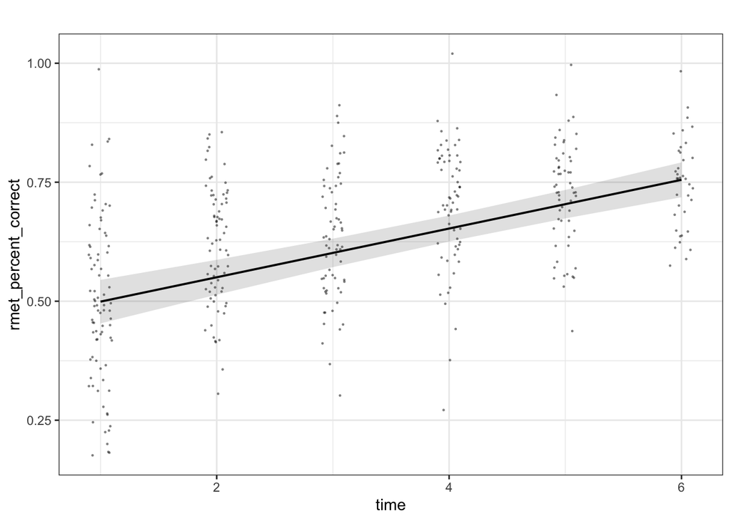

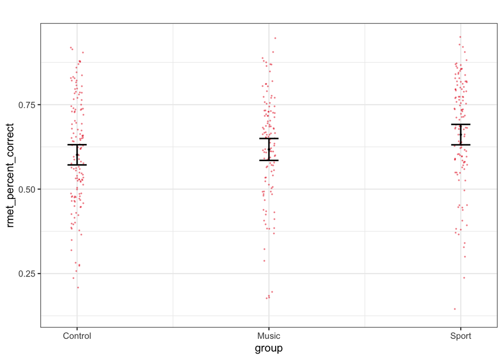

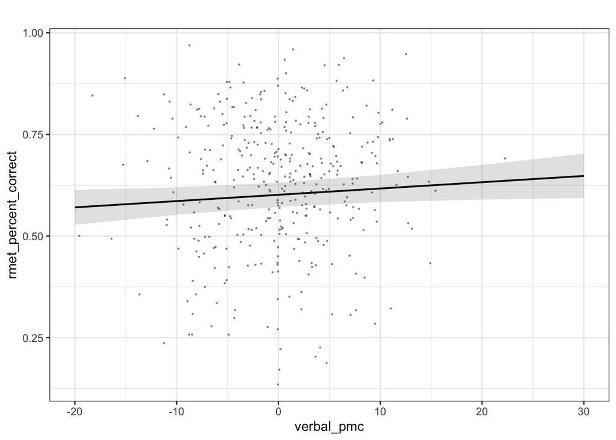

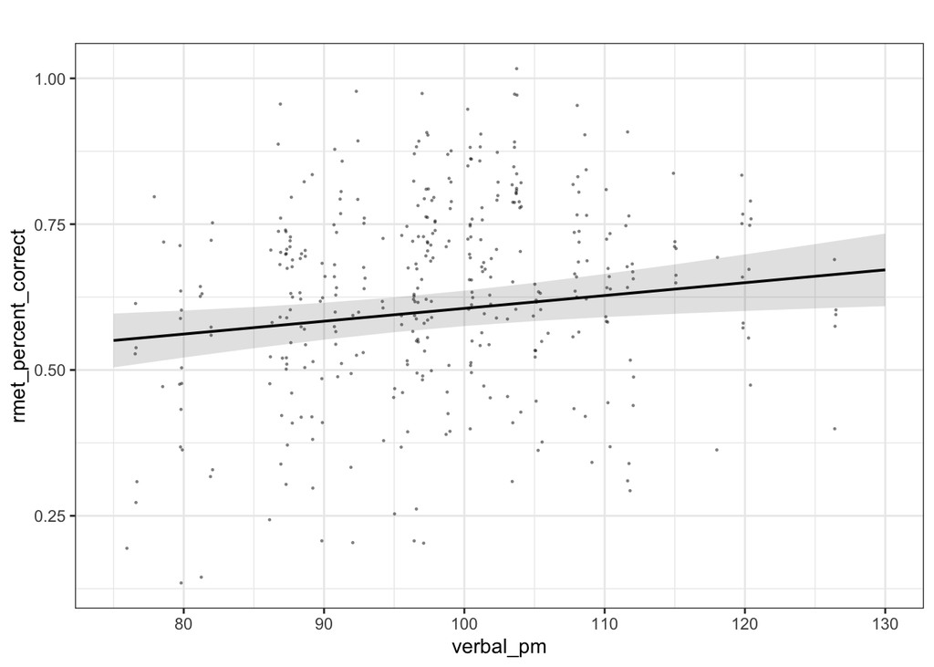

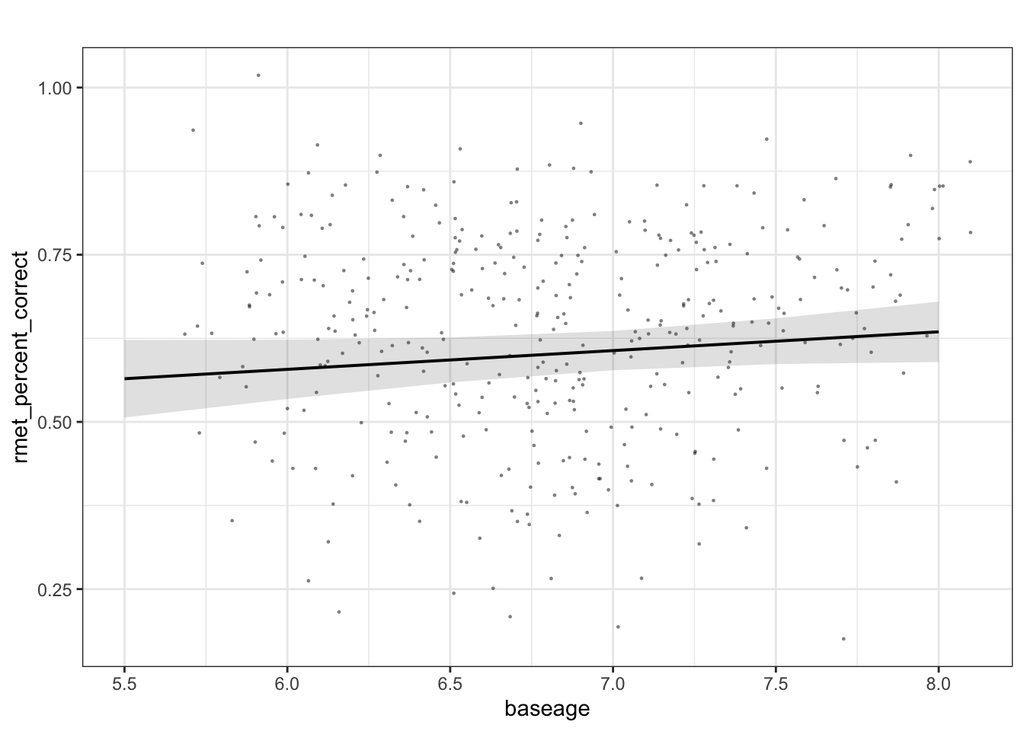

```r
plot_model(m5.1,
    type = "pred", show.data = TRUE,
    title = "", dot.size = 0.5,
    jitter = 0.1
)
```

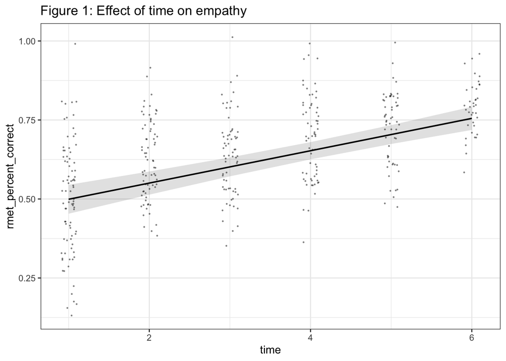

```r
plot_model(m5.1,
    type = "pred", terms = "time",
    show.data = TRUE, jitter = 0.1,
    title = "Figure 1: Effect of time on empathy ",
    dot.size = 0.5
)
```

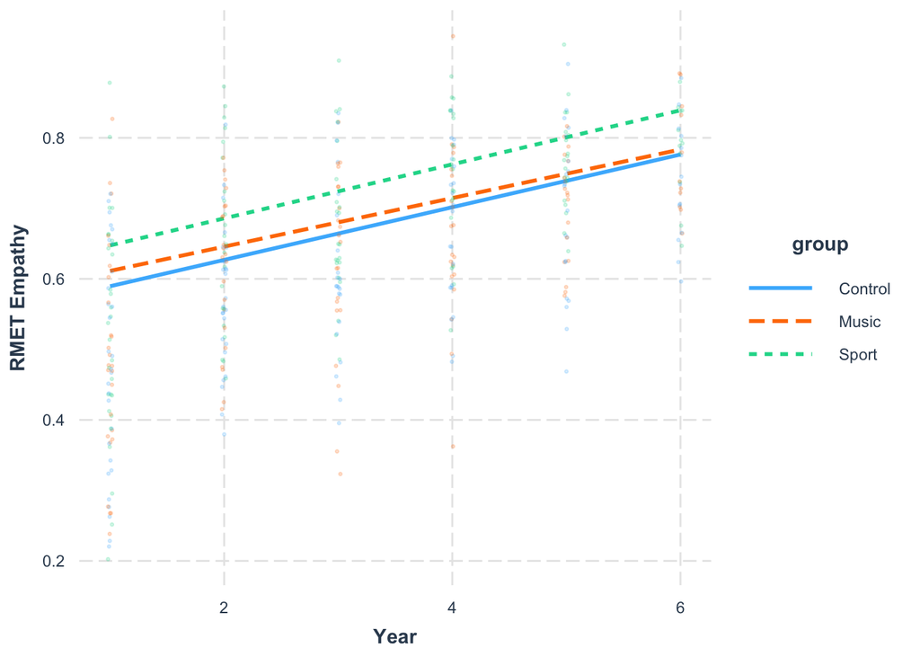

```r
# Interaction plot (year:group)
interact_plot(m5.1,
              pred = "time",
              modx = "group",
              plot.points = TRUE,
              point.size = 0.5,
              point.alpha = 0.2,
              jitter = 0.02,
              x.label = "Year",
              y.label = "RMET Empathy")
```

Summary: The results show a predicted significant increase in the RMET of 0.051 per year, regardless of group, when holding constant person mean-centered verbal IQ, participants’ mean verbal IQ, baseline age, and the interaction between time and group (95% CI [0.039, 0.063]; random slope SD = 0.022). Every unit increase in participants’ mean verbal IQ predicted a significant increase in the RMET of 0.002, when holding constant time, group, person mean-centered verbal IQ, baseline age, and the interaction between time and group (95% CI [0.001, 0.004]). Every unit increase in person mean-centered verbal IQ predicted a significant increase in RMET of 0.002, when holding constant time, group, participants’ mean verbal IQ, baseline age, and the interaction between time and group (95% CI [0.000, 0.003]). There was no significant effect of group (Music estimate = 0.025, 95% CI [-0.058, 0.107]; Sport estimate = 0.057, 95% CI [-0.023, 0.137]) or baseline age (estimate = 0.028, 95% CI [-0.006, 0.062]), and no significant interaction between group and time (Time × Music estimate = -0.003, 95% CI [-0.021, 0.015]; Time × Sport estimate = 0.001, 95% CI [-0.017, 0.019]) on the RMET, when holding constant the other variables.